# Assignment 3 - Social Network Analysis

## Part I

Start by installing the “igraph” package. Once you have installed igraph, load the package.

Now upload the data file “comment-data.csv” as a data frame called “D1”. Each row represents a comment from one student to another so the first line shows that student “28” commented on the comment of student “21”. It also shows the gender of both students and the students’ main elective field of study (“major”").

```r
D1 <- read.csv("~/Documents/HUDK4050/assignment3/comment-data.csv", header = TRUE)
```

Before you proceed, you will need to change the data type of the student id variable. Since it is a number R will automatically think it is an integer and code it as such (look at the list of variables by clicking on the data frame arrow in the Data pane. Here you will see the letters “int”" next to the stid variable, that stands for integer). However, in this case we are treating the variable as a category, there is no numeric meaning in the variable. So we need to change the format to be a category, what R calls a “factor”. We can do this with the following code:

```r
D1$comment.to <- as.factor(D1$comment.to)
D1$comment.from <- as.factor(D1$comment.from)
```

igraph requires data to be in a particular structure. There are several structures that it can use but we will be using a combination of an “edge list” and a “vertex list” in this assignment. As you might imagine the edge list contains a list of all the relationships between students and any characteristics of those edges that we might be interested in. There are two essential variables in the edge list a “from” variable and a “to” variable that descibe the relationships between vertices. While the vertex list contains all the characteristics of those vertices, in our case gender and major.

So let’s convert our data into an edge list!

First we will isolate the variables that are of interest: comment.from and comment.to

```r
library(dplyr)
D2 <- select(D1, comment.to, comment.from) #select() chooses the columns
```

Since our data represnts every time a student makes a comment there are multiple rows when the same student comments more than once on another student’s video. We want to collapse these into a single row, with a variable that shows how many times a student-student pair appears.

```r
EDGE <- count(D2, comment.to, comment.from)

names(EDGE) <- c("to", "from", "count")
```

EDGE is your edge list. Now we need to make the vertex list, a list of all the students and their characteristics in our network. Because there are some students who only recieve comments and do not give any we will need to combine the comment.from and comment.to variables to produce a complete list.

```r
#First we will separate the commenters from our commentees
V.FROM <- select(D1, comment.from, from.gender, from.major)

#Now we will separate the commentees from our commenters
V.TO <- select(D1, comment.to, to.gender, to.major)

#Make sure that the from and to data frames have the same variables names
names(V.FROM) <- c("id", "gender.from", "major.from")
names(V.TO) <- c("id", "gender.to", "major.to")

#Make sure that the id variable in both dataframes has the same number of levels
lvls <- sort(union(levels(V.FROM$id), levels(V.TO$id)))

VERTEX <- full_join(mutate(V.FROM, id=factor(id, levels=lvls)),
    mutate(V.TO, id=factor(id, levels=lvls)), by = "id")

#Fill in missing gender and major values - ifelse() will convert factors to numerical values so convert to character
VERTEX$gender.from <- ifelse(is.na(VERTEX$gender.from) == TRUE, as.factor(as.character(VERTEX$gender.to)), as.factor(as.character(VERTEX$gender.from)))

VERTEX$major.from <- ifelse(is.na(VERTEX$major.from) == TRUE, as.factor(as.character(VERTEX$major.to)), as.factor(as.character(VERTEX$major.from)))

#Remove redundant gender and major variables
VERTEX <- select(VERTEX, id, gender.from, major.from)

#rename variables
names(VERTEX) <- c("id", "gender", "major")

#Remove all the repeats so that we just have a list of each student and their characteristics
VERTEX <- unique(VERTEX)
```

Now we have both a Vertex and Edge list it is time to plot our graph!

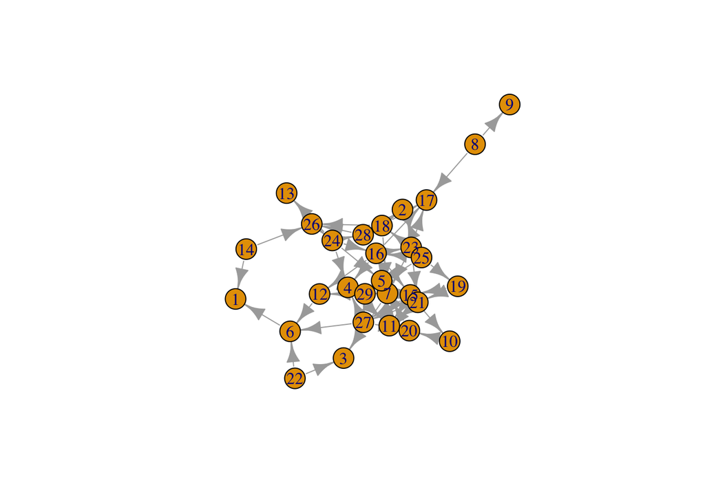

```r
#Load the igraph package

library(igraph)
#First we will make an object that contains the graph information using our two dataframes EDGE and VERTEX. Notice that we have made "directed = TRUE" - our graph is directed since comments are being given from one student to another.

g <- graph.data.frame(EDGE, directed=TRUE, vertices=VERTEX)

#Now we can plot our graph using the force directed graphing technique - our old friend Fruchertman-Reingold!

plot(g,layout=layout.fruchterman.reingold)
```

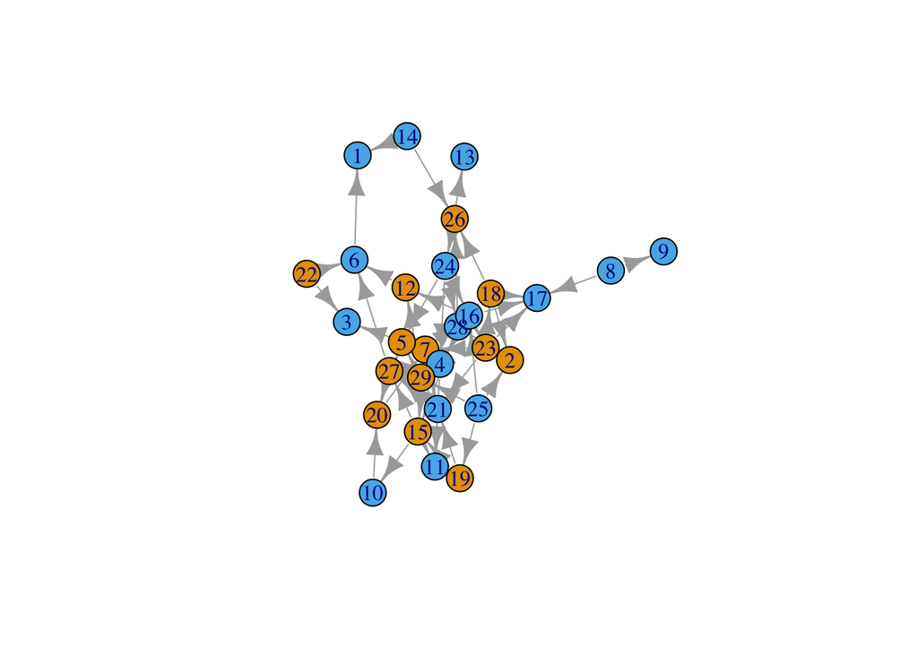

```r
#There are many ways to change the attributes of the graph to represent different characteristics of the newtork. For example, we can color the nodes according to gender.

plot(g,layout=layout.fruchterman.reingold, vertex.color=VERTEX$gender)
```

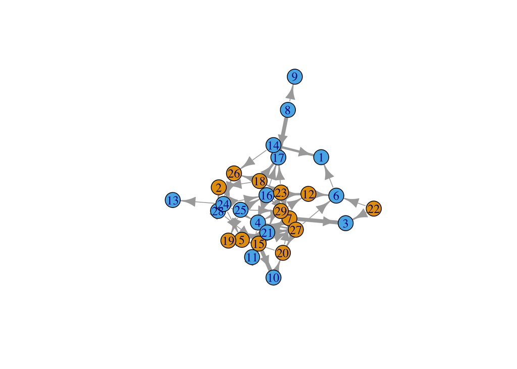

```r
#We can change the thickness of the edge according to the number of times a particular student has sent another student a comment.

plot(g,layout=layout.fruchterman.reingold, vertex.color=VERTEX$gender, edge.width=EDGE$count)
```

## Part II

In Part II your task is to [look up](http://igraph.org/r/) in the igraph documentation and modify the graph above so that: * Ensure that sizing allows for an unobstructed view of the network features (For example, the arrow size is smaller)

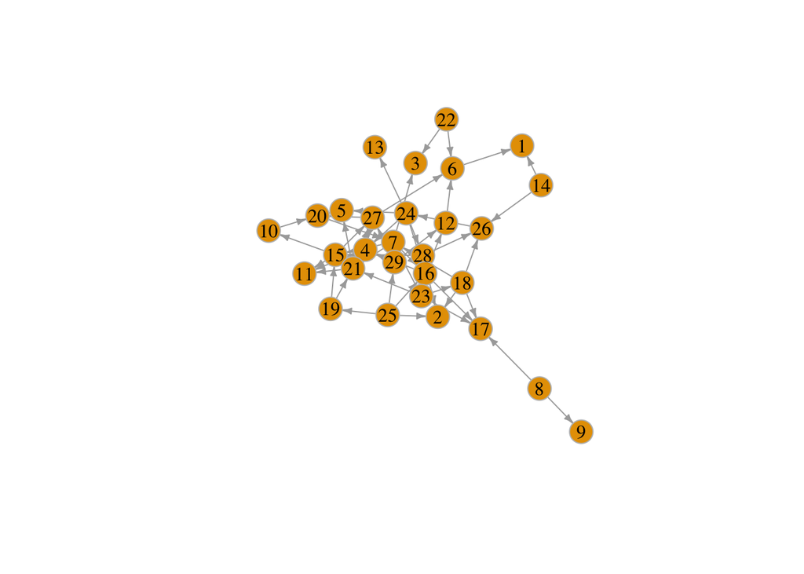

```r
plot(g,layout=layout.fruchterman.reingold, vertex.frame.color="gray",vertex.label.color="black", edge.arrow.size = 0.4, vertex.size = 15)
```

- The vertices are colored according to major

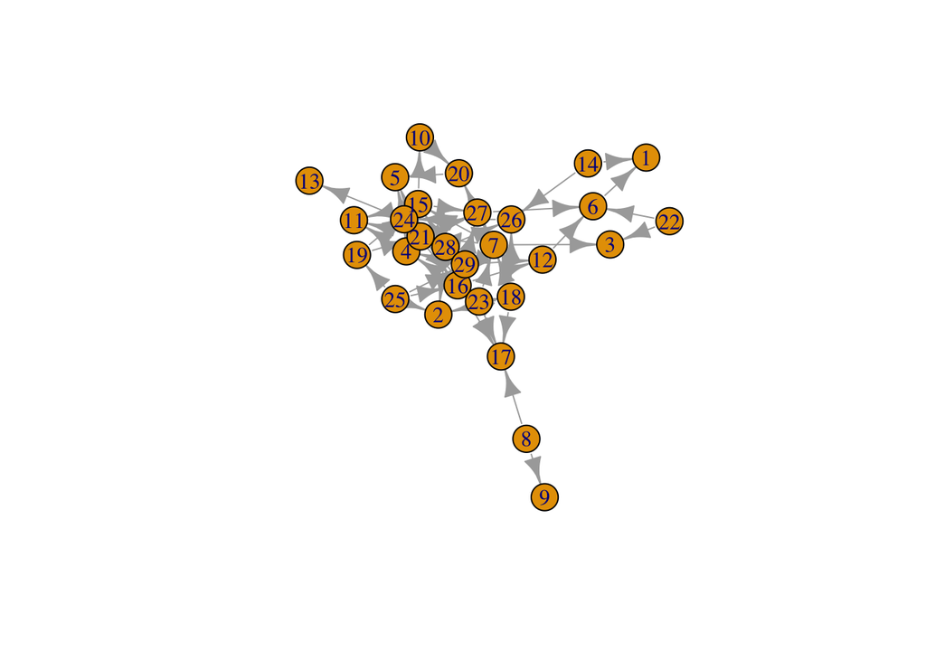

```r
plot(g,layout=layout.fruchterman.reingold)
```

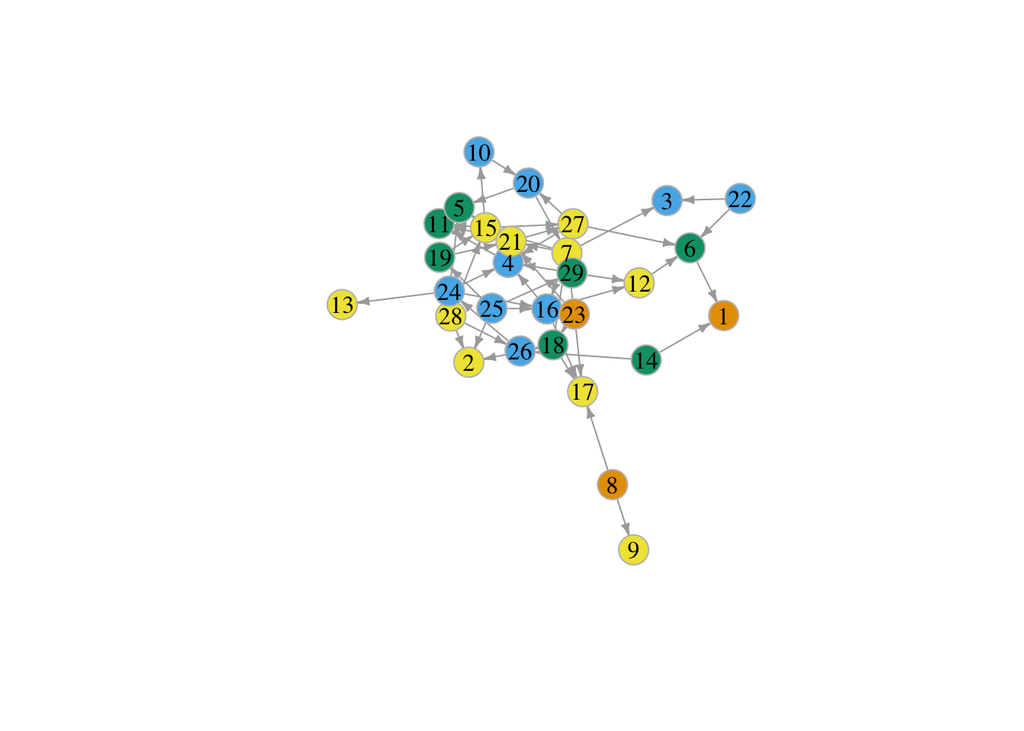

```r
plot(g,layout=layout.fruchterman.reingold, vertex.frame.color="gray",vertex.label.color="black", edge.arrow.size = 0.4, vertex.size = 15, vertex.color=VERTEX$major)
```

- The vertices are sized according to the number of comments they have recieved

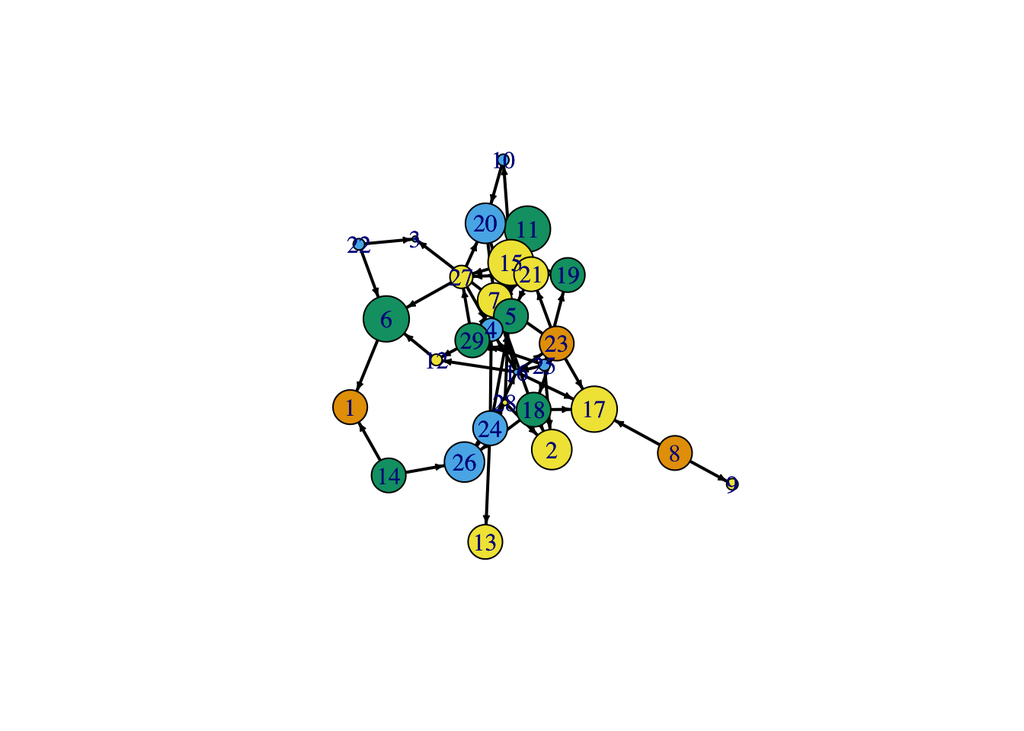

```r
library(dplyr)
library(igraph)
D3 <- EDGE %>% group_by(to) %>% mutate(received.sum = sum(count))

g <- graph.data.frame(D3, directed = TRUE, vertices=VERTEX)
plot(g, layout=layout.fruchterman.reingold, vertex.size = D3$received.sum*3, edge.arrow.size = 0.3, edge.color = "black", vertex.color = VERTEX$major, edge.width = 2)
```

## Part III

Now practice with data from our class. This data is real class data directly exported from Qualtrics and you will need to wrangle it into shape before you can work with it. Import it into R as a data frame and look at it carefully to identify problems.

Please create a **person-network** with the data set hudk4050-classes.csv. To create this network you will need to create a person-class matrix using the tidyr functions and then create a person-person matrix using `t()`. You will then need to plot a matrix rather than a to/from data frame using igraph.

Once you have done this, also [look up](http://igraph.org/r/) how to generate the following network metrics:

```r
library(tidyr)
```

```r
library(dplyr)
library(stringr)
library(igraph)
```

```r
#input data
C1 <- read.csv( "~/Documents/HUDK4050/assignment3/hudk4050-classes.csv", stringsAsFactors = FALSE, header = TRUE)
C2 <- C1
```

# Data Tidying

```r
colnames(C2) <- C2[1,]
C2 <- slice(C2, 3:49)
C2 <- select(C2, 1:8)
C2 <- unite(C2, "name", `First Name`,`Last Name`, sep = " ")
C2$name <- str_replace(C2$name, "`", "")
C2$name <- str_to_title(C2$name)
C2 <- C2 %>% mutate_at(2:7, list(toupper))
C2 <- C2 %>% mutate_at(2:7, str_replace_all, " ", "")
```

#Data restructuring

```r
C3 <- C2 %>% gather(label, class, 2:7, na.rm = TRUE, convert = FALSE) %>% select(name, class)

C3$count <- 1

C3 <- filter(C3, class != "")

C3 <- unique(C3)

C3 <- spread(C3, class, count)

rownames(C3) <- C3$name

C3 <- select(C3, -name, -HUDK4050)

C3[is.na(C3)] <- 0

C3 <- ifelse(is.na(C3), 0, 1)
```

#Matrix operation

```r
C4 <- as.matrix(C3)

C4 <- C4 %*% t(C4)
```

##graphing

[figure not shown]

```r
g <- graph.adjacency(C4, mode="undirected", diag= FALSE)
plot(g, layout=layout.fruchterman.reingold, vertex.size = 4, #degree(g)*0.7,
     vertex.label.cex=0.8,
     vertex.label.color = "black",
     vertex.color="gainsboro")
```

#betweenness

```r
sort(degree(g), decreasing = TRUE)
```

```
## Abdul Malik  Muftau         Ali  Al Jabri      Amanda Oliveira
##                 2346                 2346                 2346
##           Berj Akian            Chris Kim              Dan Lei
##                 2346                 2346                 2346
##           Danny Shan           Fangqi Liu             Fei Wang
##                 2346                 2346                 2346
##          Guoliang Xu          Hangshi Jin             He  Chen
##                 2346                 2346                 2346
##          Hyungoo Lee            Jiaao  Qi          Jiacong Zhu
##                 2346                 2346                 2346
##          Jiahao Shen          Jiasheng Yu              Jie Yao
##                 2346                 2346                 2346
##         Kaijie  Fang  Mahshad Davoodifard    Nicole Schlosberg
##                 2346                 2346                 2346
##         Qianhui Yuan            Rong Sang         Ruoyi  Zhang
##                 2346                 2346                 2346
##         Sara Vasquez        Shuying Xiong Stanley Si Heng Zhao
##                 2346                 2346                 2346
##         Tianyu Chang       Vidya Madhavan         Wenning Xiao
##                 2346                 2346                 2346
##            Wenqi Gao          Xiaojia Liu           Xijia Wang
##                 2346                 2346                 2346
##         Xiyun  Zhang          Xueshi Wang          Yifei Zhang
##                 2346                 2346                 2346
##          Yingxin Xie           Yingxin Ye           Yixiong Xu
##                 2346                 2346                 2346
##          Yucheng Pan           Yunzhao Wu           Yurui Wang
##                 2346                 2346                 2346
##          Yuting Zhou            Yuxuan Ge        Zach Friedman
##                 2346                 2346                 2346
##        Zhixin  Zheng            Zhouda Wu
##                 2346                 2346
```

```r
sort(betweenness(g), decreasing = TRUE)
```

```
## Abdul Malik  Muftau         Ali  Al Jabri      Amanda Oliveira
##                    0                    0                    0
##           Berj Akian            Chris Kim              Dan Lei
##                    0                    0                    0
##           Danny Shan           Fangqi Liu             Fei Wang
##                    0                    0                    0
##          Guoliang Xu          Hangshi Jin             He  Chen
##                    0                    0                    0
##          Hyungoo Lee            Jiaao  Qi          Jiacong Zhu
##                    0                    0                    0
##          Jiahao Shen          Jiasheng Yu              Jie Yao
##                    0                    0                    0
##         Kaijie  Fang  Mahshad Davoodifard    Nicole Schlosberg
##                    0                    0                    0
##         Qianhui Yuan            Rong Sang         Ruoyi  Zhang
##                    0                    0                    0
##         Sara Vasquez        Shuying Xiong Stanley Si Heng Zhao
##                    0                    0                    0
##         Tianyu Chang       Vidya Madhavan         Wenning Xiao
##                    0                    0                    0
##            Wenqi Gao          Xiaojia Liu           Xijia Wang
##                    0                    0                    0
##         Xiyun  Zhang          Xueshi Wang          Yifei Zhang
##                    0                    0                    0
##          Yingxin Xie           Yingxin Ye           Yixiong Xu
##                    0                    0                    0
##          Yucheng Pan           Yunzhao Wu           Yurui Wang
##                    0                    0                    0
##          Yuting Zhou            Yuxuan Ge        Zach Friedman
##                    0                    0                    0
##        Zhixin  Zheng            Zhouda Wu
##                    0                    0
```

- Betweeness centrality and dregree centrality. **Who is the most central person in the network according to these two metrics? Write a sentence or two that describes your interpretation of these metrics**

- Color the nodes according to interest. Are there any clusters of interest that correspond to clusters in the network? Write a sentence or two describing your interpetation.

### To Submit Your Assignment

Please submit your assignment by first “knitting” your RMarkdown document into an html file and then comit, push and pull request both the RMarkdown file and the html file.